# Homework session 2

Eystein Nordby Meese

23 10 2019

# 1 Introduksjon

# 2 Enkle Funksjoner

## 2.1 Summer to tall

```r
x <- c(1, 2, 3, 10)
y <- c(4, 5, 6, 23)

sum_two_numbers <- function(x,y) {
  x + y
}

sum_two_numbers(x,y)
```

```
## [1]  5  7  9 33
```

## 2.2 Multipliser to tall

```r
multiply_two_numbers <- function(x,y) {
  x * y
}

multiply_two_numbers(x,y)
```

```
## [1]   4  10  18 230
```

## 2.3 Feilmelding

Dersom vi kjører kvadrer_x(), så vil vi få feilmeldingen “x” mangler, med ingen default. Dette fordi funksjonen krever en verdi på x for å ut en output. Den klarer ikke, logisk nok, å kjøre ingenting opphøyd i andre.

Vi kan fikse dette med å legge inn en default verdi for x i funksjonen, som for eksempel kan være enten 0 eller NA:

```r
kvadrer_x <- function(x = 0) {
  x^2
}

kvadrer_x()
```

```
## [1] 0
```

## 2.4 Default value cor()

At default verdien til for method i cor er c(“pearson”, “kendall”, “spearman”) betyr at det er en av disse metodene som blir brukt i beregningen av kovarians eller correlation. Dette er noe forskjellige beregningsmetoder, og det er en av disse tre som kan benyttes i funksjonen.

Den faktiske default-verdien, hvis man ikke spesifiserer en metode, er den første verdien - “pearson”.

## 2.5 Finnes 2 i vektoren?

```r
number_two_included <-  function(x) {
  2 %in% x
}

number_two_included(x)
```

```
## [1] TRUE
```

```r
number_two_included(y)
```

```
## [1] FALSE
```

## 2.6 Dårlig ide

Det er en dårlig ide å gi funksjonen sin navn som sum(), mtcars() eller mean(), da dette allerede er funksjoner som finnes i base pakken i R, og man vil da fort kunne forveksle mellom dem, og det er lett å bruke feil funksjon i koden sin.

## 2.7 Partall

```r
er_partall <- function(x) {
    if(is.integer(x)) {
      x %% 2 ==  0
    } else {
      stop("Number must be of type integer", call. = FALSE)
  }
}

#er_partall(x)

z <- as.integer(x)

er_partall(z)
```

```
## [1] FALSE  TRUE FALSE  TRUE
```

Man trenger ikke lage er_oddetall() når vi lager er_partall(), siden er_partall() returnerer FALSE dersom inputen ikke er partall, noe som betyr at inputen er oddetall. Mao. TRUE = partall, mens FALSE = oddetall.

## 2.8 If Else Ifelse

Forskjellen mellom if() og ifelse() er at if() vil kun se på det første elementet i en vektor, mens ifelse() vil se på alle elementene individuelt i vektoren. if() statementet er en kontroll statement som er utviklet til å virke bare mot en scalar boolean condition.

if() funksjonen ville jeg brukt i byggingen av egne funksjoner, for å kjøre en viss funksjonsdel når en gitt tilstand er sann, eksempelvis når (x %% 2) = 0 (x er partall), mens ifelse() ville jeg brukt i transformering av input-dataen. Eksempel på ifelse:  
ifelse(x==2, 1, 0). I dette eksempelet vil alle elementene i vektoren som er 2 bli transformert til 1, mens de som ikke er vil bli til 0.

## 2.9 Funksjonen virker ikke

Funksjonen vil ikke virke fordi den ikke ikke skjønner at “variabel” er en kolonne, men tror at det er et objekt. For å fikse funksjonen kan vi legge til 2 brackets rundt “variabel”, da vil funksjonen skjønne at det er et variabelnavn på en kolonne:

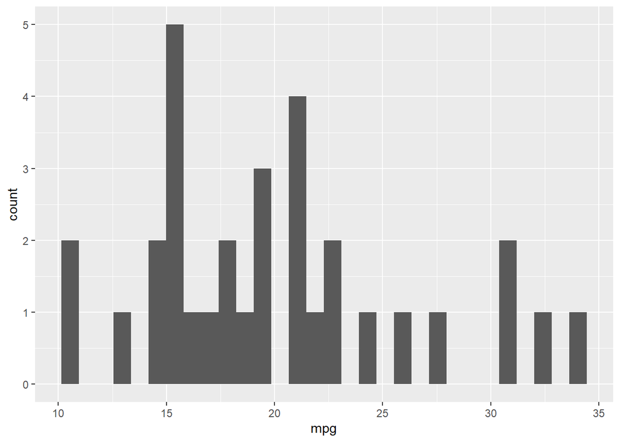

```r
lag_histogram <-  function(.data, variabel) {

  .data %>%
    ggplot(aes(x = {{variabel}})) +
    geom_histogram()

}

lag_histogram(mtcars, mpg)
```

# 3 God

Skriv en funksjon som returner “God morgen”, “God formiddag”, “God ettermiddag” eller “God kveld” avhengig av hvilket tidspunkt man sender som input.

Tips: Bruk lubridate::now() som default, da blir det lettere å teste funksjonen.

```r
lubridate::hour(now())
```

```
## [1] 9
```

```r
time_of_day <- function(timeofday = hour(now())) {
  if(between(timeofday, 06.01, 09.00)) {
    return("God morgen")
  } else {
    if(between(timeofday, 09.01, 12.00)) {
      return("God formiddag")
    } else {
    if(between(timeofday, 12.01, 17.00)) {
      return("God ettermiddag")
    } else {
    if(between(timeofday, 17.01, 24.00)) {
      return("God kveld")
    } else {
    if(between(timeofday, 00.01, 06.00)) {
      return("GÅ Å LEGG DEG!")
    } else {
      stop("Feil verdi! timeofday må ha en verdi mellom
           00.00 og 24.00", call. = FALSE)
          }
        }
      }
    }
  }
}

time_of_day()
```

```
## [1] "God morgen"
```

# 4 Konverteringer 1

```r
fahrenheit_to_celsius <- function(fahrenheit = NA) {
  if(is.character(fahrenheit)) {
    stop("Fahrenheit kan ikke være av karakter, må være et nummer!", call. = FALSE)
  }
  celsius <- round((fahrenheit - 32) * (5/9), 0)
  print(celsius)
}

celsius_to_fahrenheit <- function(celsius = NA) {
  if(is.character(celsius)) {
    stop("Celsius kan ikke være av karakter, må være et nummer!", call. = FALSE)
  }
  fahrenheit <- round((celsius * (9/5) + 32), 0)
  print(fahrenheit)
}


fahrenheit_to_celsius(32)
```

```
## [1] 0
```

```r
fahrenheit_to_celsius(64)
```

```
## [1] 18
```

```r
celsius_to_fahrenheit(0)
```

```
## [1] 32
```

```r
celsius_to_fahrenheit(100)
```

```
## [1] 212
```

```r
# Denne ser feil ut, må fikses.
fahrenheit_to_celsius(celsius_to_fahrenheit(23))
```

```
## [1] 73
## [1] 23
```

# 5 DingDong

```r
dingdong <- function(x) {
  x <- as.data.frame(x) %>%
    mutate(x = case_when(
      x %% 15 == 0 ~ "DingDong",
      x %% 3 == 0 ~ "Ding",
      x %% 5 == 0 ~ "Dong",
      TRUE ~ as.character(x)
    )) %>%
    print(x)
}


dingdong(c(1:100))
```

```
##            x
## 1          1
## 2          2
## 3       Ding
## 4          4
## 5       Dong
## 6       Ding
## 7          7
## 8          8
## 9       Ding
## 10      Dong
## 11        11
## 12      Ding
## 13        13
## 14        14
```

[output cut: 86 more lines]

# 6 print_all

```r
print_all <- function(data) {
  print(data, n = nrow(data))
}

# For å teste funksjonen
iris %>% as_tibble %>% head(25) %>%  print_all()
```

```
## # A tibble: 25 x 5
##    Sepal.Length Sepal.Width Petal.Length Petal.Width Species
##           <dbl>       <dbl>        <dbl>       <dbl> <fct>
##  1          5.1         3.5          1.4         0.2 setosa
##  2          4.9         3            1.4         0.2 setosa
##  3          4.7         3.2          1.3         0.2 setosa
##  4          4.6         3.1          1.5         0.2 setosa
##  5          5           3.6          1.4         0.2 setosa
##  6          5.4         3.9          1.7         0.4 setosa
##  7          4.6         3.4          1.4         0.3 setosa
##  8          5           3.4          1.5         0.2 setosa
##  9          4.4         2.9          1.4         0.2 setosa
## 10          4.9         3.1          1.5         0.1 setosa
## 11          5.4         3.7          1.5         0.2 setosa
## 12          4.8         3.4          1.6         0.2 setosa
## 13          4.8         3            1.4         0.1 setosa
## 14          4.3         3            1.1         0.1 setosa
## 15          5.8         4            1.2         0.2 setosa
## 16          5.7         4.4          1.5         0.4 setosa
## 17          5.4         3.9          1.3         0.4 setosa
## 18          5.1         3.5          1.4         0.3 setosa
## 19          5.7         3.8          1.7         0.3 setosa
## 20          5.1         3.8          1.5         0.3 setosa
## 21          5.4         3.4          1.7         0.2 setosa
## 22          5.1         3.7          1.5         0.4 setosa
## 23          4.6         3.6          1           0.2 setosa
## 24          5.1         3.3          1.7         0.5 setosa
## 25          4.8         3.4          1.9         0.2 setosa
```

# 7 Passordgenerator

Funksjon som generer en tilfeldig string av valgfri lengde, som kun kan inneholde:  
- Store bokstaver (engelsk)  
- Små bokstaver (engelsk)  
- Tall fra 0-9

```r
generate_password <- function(length = NA) {

  numbers <- c(0:9)
  lower_char <- letters
  upper_char <- LETTERS

  password <- paste0(sample(c(numbers,
                              lower_char,
                              upper_char),
                            length,
                            replace = TRUE),
                     collapse = "")

  return(password)
}

generate_password(16)
```

```
## [1] "E9c3dXWXRROAQ42n"
```

# 8 NA-funksjoner

```r
antall_na <- function(variabel) {
    sum(is.na(variabel))
}

prosent_na <- function(variabel) {
  pros_na <- round((antall_na(variabel)/length(variabel))*100,2)
  return(pros_na)
}

library(nycflights13)

antall_na(flights$dep_time)
```

```
## [1] 8255
```

```r
prosent_na(variabel = flights$dep_time)
```

```
## [1] 2.45
```

```r
map_dfr(flights, ~ antall_na(.x))
```

```
## # A tibble: 1 x 19
##    year month   day dep_time sched_dep_time dep_delay arr_time
##   <int> <int> <int>    <int>          <int>     <int>    <int>
## 1     0     0     0     8255              0      8255     8713
## # ... with 12 more variables: sched_arr_time <int>, arr_delay <int>,
## #   carrier <int>, flight <int>, tailnum <int>, origin <int>, dest <int>,
## #   air_time <int>, distance <int>, hour <int>, minute <int>,
## #   time_hour <int>
```

# 9 Innlastning av mange datafiler

```r
getwd()
```

```
## [1] "C:/Users/NO100464/Documents/R/R-kurs_del2"
```

```r
file_path <- fs::dir_ls(path = "./Data/Karakterer_per_fylke",
                        regexp = "\\~csv$")

karakterer_per_fylke <- file_path %>%
  map_df(~read_csv(.x, col_types = cols(.default = "c")))


tbl <-
    list.files(path = "./Data/Karakterer_per_fylke",
               pattern = "*.csv",
               full.names = T) %>%
    map_df(~read_csv2(., col_types = cols(.default = "c")))

karakterer_per_fylke <- tbl %>%
  as.data.frame() %>%
  na.omit()
```

# 10 Fleksible Plots

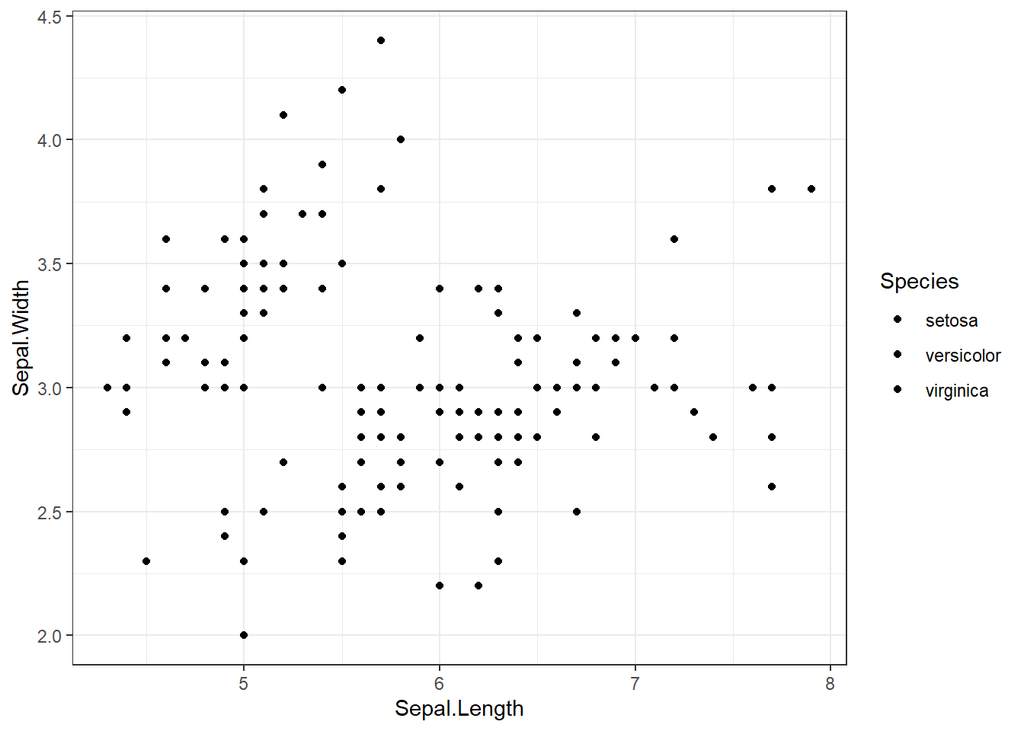

```r
# If NA, remove obs. LEGG TIL
# FIKS FARGER

make_plot <- function(data, x, y, z, theme = theme_bw()) {
  myColors <- brewer.pal(12, name = "Set3")
  names(myColors) <- unique(data$z)

  data %>%
    ggplot(aes({{x}},{{y}}, fill = {{z}})) +
    geom_point() +
    scale_colour_manual(values = myColors) +
    theme
}


iris %>%
  make_plot(Sepal.Length, Sepal.Width, Species, theme_bw())
```

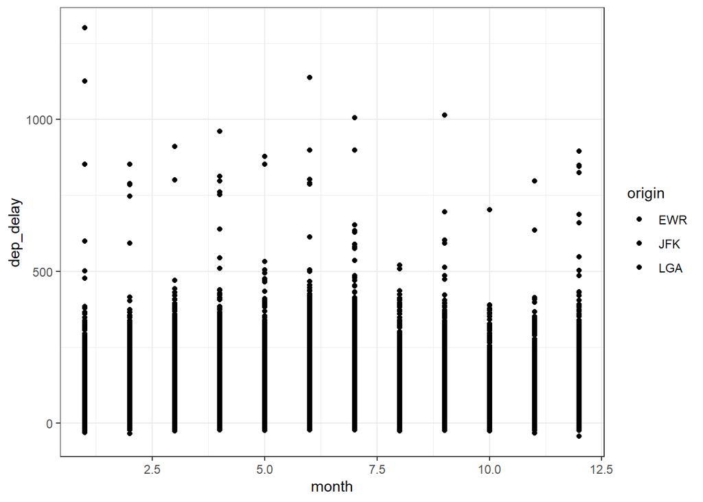

```r
flights %>%
  make_plot(month, dep_delay, origin)
```

# 11 Konverteringer 2

```r
mpg_to_kpl <- function(mpg = NA) {
   kpl <- round((mpg/2.352137783), 4)
  print(kpl)
}

mpg_to_kpl(1)
```

```
## [1] 0.4251
```

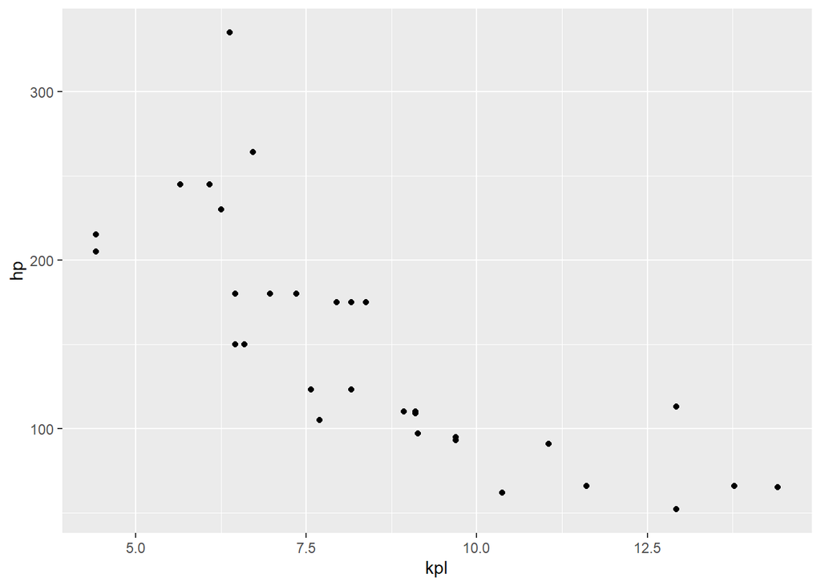

```
##  [1]  8.9280  8.9280  9.6933  9.0981  7.9502  7.6951  6.0796 10.3735
##  [9]  9.6933  8.1628  7.5676  6.9724  7.3550  6.4622  4.4215  4.4215
## [17]  6.2496 13.7747 12.9244 14.4124  9.1406  6.5898  6.4622  5.6544
## [25]  8.1628 11.6065 11.0538 12.9244  6.7173  8.3754  6.3772  9.0981
##  [1]  8.9280  8.9280  9.6933  9.0981  7.9502  7.6951  6.0796 10.3735
##  [9]  9.6933  8.1628  7.5676  6.9724  7.3550  6.4622  4.4215  4.4215
## [17]  6.2496 13.7747 12.9244 14.4124  9.1406  6.5898  6.4622  5.6544
## [25]  8.1628 11.6065 11.0538 12.9244  6.7173  8.3754  6.3772  9.0981
```

```r
plot_kpl <- function(data, mpg, y) {
  data %>%
    ggplot(aes(mpg_to_kpl({{mpg}}), {{y}})) +
    geom_point() +
    labs(x = "kpl")
}

mtcars %>% plot_kpl(mpg, hp)
```

# 12 Rescale

Lag en funksjon som tar en vektor som input og reskalerer til at første verdi er lik 100 og resterende verdier viser riktig prosentvis størrelse i forhold til start. Det vil si at for eksempel c(10, 9, 15) reskaleres til c(100, 90, 150).

```r
rescaling <- function(x) {
  if(class(x) != "numeric") {
    return(x)
  }
  x <- as.vector(x/x[1])*100

  return(x)
}

x <- c(10,9,15)

rescaling(x)
```

```
## [1] 100  90 150
```

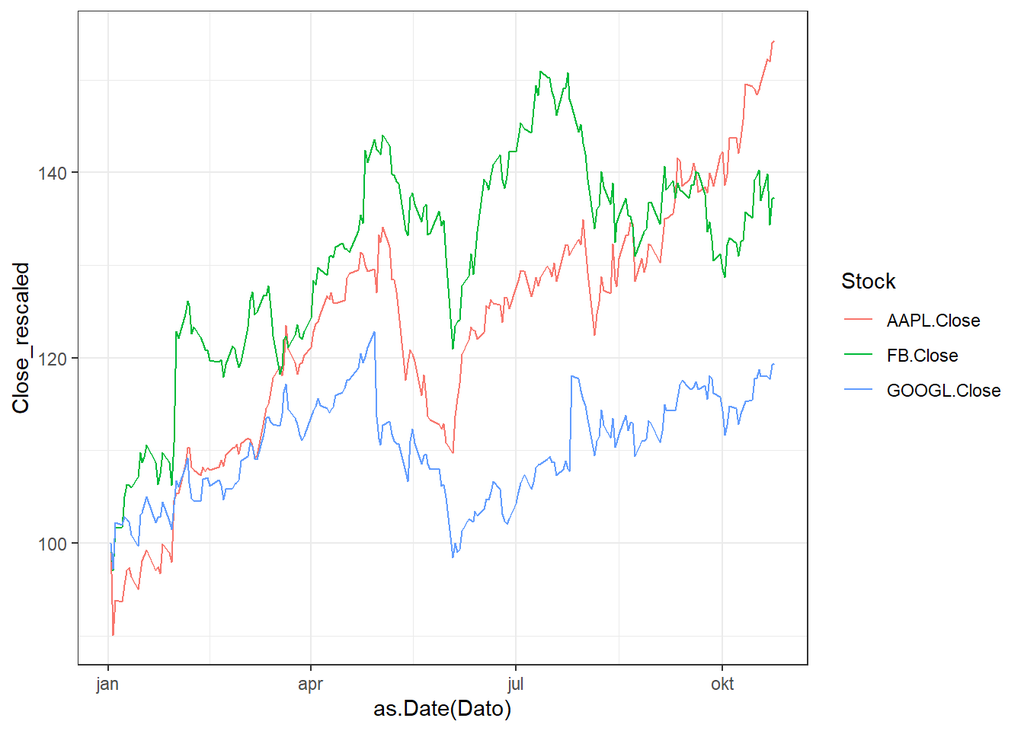

```r
# Plot
df_stocks %>%
  mutate(FB.Close = rescaling(FB.Close),
         GOOGL.Close = rescaling(GOOGL.Close),
         AAPL.Close = rescaling(AAPL.Close)) %>%
  select(Dato, contains("Close")) %>%
  pivot_longer(-Dato, names_to = "Stock", values_to = "Close_rescaled") %>%
  ggplot(aes(x = as.Date(Dato), y = Close_rescaled, col = Stock, group = Stock)) +
  geom_line() +
  theme_bw()
```

# 13 Navngiving

```r
test_first_symbol <- function(string, prefix) {
  substr(string, 1, nchar(prefix)) == prefix
}

del_last_obs <- function(x) {
  if (length(x) <= 1) return(NULL)
  x[-length(x)]
}

rep_length <- function(x, y) {
  rep(y, length.out = length(x))
}

return_min_of_max <- function(x, y, z) {
  pmin(pmax(x, y), z)
}
```

# 14 Bli kvitt for-løkken

```r
out <- function(x = letters) {
  out <- paste0(gsub(",", "", x), collapse = "")
  return(out)
}
out()
```

```
## [1] "abcdefghijklmnopqrstuvwxyz"
```

```r
set.seed(1)
x <- sample(100)
sd <- 0
for (i in seq_along(x)) {
  sd <- sd + (x[i] - mean(x)) ^ 2
}
sd <- sqrt(sd / (length(x) - 1))

standard_dev <- function(x) {
  stand_dev <- (sd(x))
  return(stand_dev)
}

# Tester at gir samme output
sd
```

```
## [1] 29.01149
```

```r
standard_dev(x)
```

```
## [1] 29.01149
```

```r
x <- runif(100)
out <- vector("numeric", length(x))
out[1] <- x[1]
for (i in 2:length(x)) {
  out[i] <- out[i - 1] + x[i]
}

cumming <- function(x) {
  out <- cumsum(x)
  return(out)
}

# Tester at gir samme output
out
```

```
##   [1]  0.6827881  1.2843293  1.5231980  1.7813639  2.5106735  2.9632444
##   [7]  3.1383711  3.8850694  3.9900570  4.8546020  5.4692470  6.0264065
##  [13]  6.3551838  6.8083153  7.3087562  7.4896226  8.0192532  8.0945289
##  [19]  8.3722849  8.5849844  8.8697749  9.7648690 10.2111043 10.9910892
##  [25] 11.8717082 12.2848324 12.3486409 12.6841284 13.4078544 13.7454697
##  [31] 14.3758838 15.2164984 16.0726300 16.4639893 16.8444832 17.7399286
##  [37] 18.3842444 19.1253230 19.7306265 20.6337081 20.9274382 21.1186984
##  [43] 22.0051493 22.5084888 23.3855463 23.5747399 24.3328430 25.0573419
##  [49] 26.0010667 26.5487133 27.2604572 27.6493623 27.7502354 28.6775375
##  [55] 28.9607700 29.5513431 29.6617037 30.5022108 30.8201745 31.6030258
##  [61] 31.8705340 32.0891793 32.6059761 32.8749267 33.0560950 33.5746712
##  [67] 34.1374541 34.2666110 34.5229786 35.2409139 36.2023238 36.3024646
##  [73] 37.0656873 38.0136537 38.8322884 39.1405807 39.7901602 40.7435156
##  [79] 41.6972483 42.0372275 42.2997016 42.4651555 42.7873236 43.2974488
##  [85] 44.2214172 44.7323769 44.9899982 45.0364591 45.4543153 46.3083169
##  [91] 46.6555475 46.7869898 47.1614767 47.7928969 48.1829759 48.8726037
##  [97] 49.5620171 50.1169178 50.5465422 50.9992622
```

```r
cumsum(x)
```

```
##   [1]  0.6827881  1.2843293  1.5231980  1.7813639  2.5106735  2.9632444
##   [7]  3.1383711  3.8850694  3.9900570  4.8546020  5.4692470  6.0264065
##  [13]  6.3551838  6.8083153  7.3087562  7.4896226  8.0192532  8.0945289
##  [19]  8.3722849  8.5849844  8.8697749  9.7648690 10.2111043 10.9910892
##  [25] 11.8717082 12.2848324 12.3486409 12.6841284 13.4078544 13.7454697
##  [31] 14.3758838 15.2164984 16.0726300 16.4639893 16.8444832 17.7399286
##  [37] 18.3842444 19.1253230 19.7306265 20.6337081 20.9274382 21.1186984
##  [43] 22.0051493 22.5084888 23.3855463 23.5747399 24.3328430 25.0573419
##  [49] 26.0010667 26.5487133 27.2604572 27.6493623 27.7502354 28.6775375
##  [55] 28.9607700 29.5513431 29.6617037 30.5022108 30.8201745 31.6030258
##  [61] 31.8705340 32.0891793 32.6059761 32.8749267 33.0560950 33.5746712
##  [67] 34.1374541 34.2666110 34.5229786 35.2409139 36.2023238 36.3024646
##  [73] 37.0656873 38.0136537 38.8322884 39.1405807 39.7901602 40.7435156
##  [79] 41.6972483 42.0372275 42.2997016 42.4651555 42.7873236 43.2974488
##  [85] 44.2214172 44.7323769 44.9899982 45.0364591 45.4543153 46.3083169
##  [91] 46.6555475 46.7869898 47.1614767 47.7928969 48.1829759 48.8726037
##  [97] 49.5620171 50.1169178 50.5465422 50.9992622
```

# 15 Feilmeldinger